# EDA

Alejandro Muñoz

23/1/2022

#### Proyecto

Cancelaciones en Hoteles Predecir cancelación de reservas en hoteles - AM 2021

#### Descripción del problema

Con el fin de planear tarifas y actividades de ventas o promoción, los hoteles hacen estimaciones adelantadas de su ocupación en cada día. Una parte de estas estimaciones requiere predecir cuántas de las reservaciones que ya se tienen van a terminar en cancelaciones, lo cual libera inventario que afecta en la planeación.

#### Objetivo

Predecir cuáles reservaciones son probables que terminen o no en cancelación.

#### Fuente de datos

Los datos que se utilizaron para este proyecto fueron obtenidos del sitio

https://www.kaggle.com/c/cancelaciones-en-hoteles/data

Los datos originales provienen de Hotel booking demand datasets, Antonio, de Almeida, Nunes (https://www.sciencedirect.com/science/article/pii/S2352340918315191)

#### Variables

Variable | Tipo | Descripción |  
ADR | Numeric | Tarifa diaria promedio definida por [5] |  
Adults | Integer | Número de Adultos |  
Agent | Categorical | DNI de la agencia de viajes que realizó la reservaa |  
ArrivalDateDayOfMonth | Integer | Día del mes de la fecha de llegada |  
ArrivalDateMonth | Categorical | Mes de la fecha de llegada con 12 categorías: “enero” a “diciembre” |  
ArrivalDateWeekNumber | Integer | Número de semana de la fecha de llegada |  
ArrivalDateYear | Integer | Año de la fecha de llegada |  
AssignedRoomType | Categorical | Código del tipo de habitación asignada a la reserva. A veces, el tipo de habitación asignada difiere del tipo de habitación reservada debido a razones de operación del hotel (por ejemplo, overbooking) o por solicitud del cliente. El código se presenta en lugar de la designación por razones de anonimato |  
Babies | Integer | Numero de bebes |  
BookingChanges | Integer | Número de cambios / modificaciones realizadas a la reserva desde el momento en que se ingresó la reserva en el PMS hasta el momento del check-in o la cancelación |  
Children | Integer | Numero de niños |  
Company | Categorical | DNI de la empresa / entidad que realizó la reserva o responsable del pago de la reserva. La identificación se presenta en lugar de la designación por razones de anonimato |  
Country | Categorical | País de origen. Las categorías están representadas en el formato ISO 3155-3: 2013 [6] |  
CustomerType | Categorical | Tipo de reserva, asumiendo una de cuatro categorías: |  
DaysInWaitingList | Integer | Número de días que la reserva estuvo en lista de espera antes de que fuera confirmada al cliente |  
DepositType | Categorical | Indicación sobre si el cliente realizó un depósito para garantizar la reserva. Esta variable puede asumir tres categorías: |  
DistributionChannel | Categorical | Canal de distribución de reservas. El término “TA” significa “Agentes de viajes” y “TO” significa “Operadores turísticos” |  
IsCanceled | Categorical | Valor que indica si la reserva fue cancelada (1) o no (0) |  
IsRepeatedGuest | Categorical | Valor que indica si el nombre de la reserva fue de un huésped repetido (1) o no (0) |  
LeadTime | Integer | Número de días transcurridos entre la fecha de entrada de la reserva en el PMS y la fecha de llegada |  
MarketSegment | Categorical | Designación de segmento de mercado. En las categorías, el término “TA” significa “Agentes de viajes” y “TO” significa “Operadores turísticos” |  
Meal | Categorical | Tipo de comida reservada. Las categorías se presentan en paquetes de comidas de hospitalidad estándar: |  
PreviousBookingsNotCanceled | Integer | Número de reservas anteriores no canceladas por el cliente antes de la reserva actual |  
PreviousCancellations | Integer | Número de reservas anteriores que fueron canceladas por el cliente antes de la reserva actual |  
RequiredCardParkingSpaces | Integer | Número de plazas de aparcamiento requeridas por el cliente |  
ReservationStatus | Categorical | Último estado de la reserva, asumiendo una de tres categorías: |  
ReservationStatusDate | Date | Fecha en la que se estableció el último estado. Esta variable se puede utilizar junto con ReservationStatus para comprender cuándo se canceló la reserva o cuándo se registró el cliente en el hotel. |  
ReservedRoomType | Categorical | Código del tipo de habitación reservado. El código se presenta en lugar de la designación por razones de anonimato |  
StaysInWeekendNights | Integer | Número de noches de fin de semana (sábado o domingo) que el huésped se hospedó o reservó para alojarse en el hotel |  
StaysInWeekNights | Integer | Número de noches de la semana (de lunes a viernes) que el huésped se hospedó o reservó para alojarse en el hotel |  
TotalOfSpecialRequests | Integer | Número de solicitudes especiales realizadas por el cliente (por ejemplo, dos camas individuales o piso alto) |

### Analisis Exploratorio de Datos

Con el fin de entender los datos realizamos una revisión general de estos y tratamos de identificar aquellas variables que pudieran ser interesantes para nuestro estudio

```r
library(tidyverse)
library(Hmisc)
library(skimr)
library(naniar)
library(patchwork)
```

```r
library(plotly)
library(ggplot2)
library(DataExplorer)
library(knitr)
library(reshape2)
if(!require("PerformanceAnalytics")) install.packages("PerformanceAnalytics")
if(!require("corrplot")) install.packages("corrplot")
library(PerformanceAnalytics)
library(corrplot)
```

#### Se leen los datos de Entrenamiento

```r
data<-read.csv("data/entrena.csv",stringsAsFactors = F)
```

```r
idx <- sample(seq(1, 3), size = nrow(data), replace = TRUE, prob = c(.7, 2, .1))
train <- data[idx == 1,]
test <- data[idx == 2,]
cal <- data[idx == 3,]
```

#### Usamos la función skim en la base de datos de entrenamiento para conocer las características generales de cada variable

```r
skim(train)
```

Data summary

| Name | train |
| --- | --- |
| Number of rows | 22789 |
| Number of columns | 30 |
| _______________________ |  |
| Column type frequency: |  |
| character | 13 |
| numeric | 17 |
| ________________________ |  |
| Group variables | None |

**Variable type: character**

| skim_variable | n_missing | complete_rate | min | max | empty | n_unique | whitespace |
| --- | --- | --- | --- | --- | --- | --- | --- |
| hotel | 0 | 1 | 10 | 12 | 0 | 2 | 0 |
| is_canceled | 0 | 1 | 9 | 12 | 0 | 2 | 0 |
| arrival_date_month | 0 | 1 | 3 | 9 | 0 | 12 | 0 |
| meal | 0 | 1 | 2 | 9 | 0 | 5 | 0 |
| country | 0 | 1 | 2 | 4 | 0 | 124 | 0 |
| market_segment | 0 | 1 | 6 | 13 | 0 | 7 | 0 |
| distribution_channel | 0 | 1 | 3 | 9 | 0 | 5 | 0 |
| reserved_room_type | 0 | 1 | 1 | 1 | 0 | 10 | 0 |
| assigned_room_type | 0 | 1 | 1 | 1 | 0 | 11 | 0 |
| deposit_type | 0 | 1 | 10 | 10 | 0 | 3 | 0 |
| agent | 0 | 1 | 1 | 4 | 0 | 240 | 0 |
| company | 0 | 1 | 1 | 4 | 0 | 212 | 0 |
| customer_type | 0 | 1 | 5 | 15 | 0 | 4 | 0 |

**Variable type: numeric**

| skim_variable | n_missing | complete_rate | mean | sd | p0 | p25 | p50 | p75 | p100 | hist |
| --- | --- | --- | --- | --- | --- | --- | --- | --- | --- | --- |
| lead_time | 0 | 1 | 96.14 | 105.19 | 0 | 15 | 58.0 | 144.00 | 737.0 | ▇▂▁▁▁ |
| arrival_date_year | 0 | 1 | 2015.90 | 0.61 | 2015 | 2016 | 2016.0 | 2016.00 | 2017.0 | ▃▁▇▁▂ |
| arrival_date_week_number | 0 | 1 | 28.17 | 14.98 | 1 | 13 | 30.0 | 41.00 | 53.0 | ▆▅▆▇▆ |
| arrival_date_day_of_month | 0 | 1 | 15.85 | 8.73 | 1 | 8 | 16.0 | 23.00 | 31.0 | ▇▇▇▇▆ |
| stays_in_weekend_nights | 0 | 1 | 0.89 | 0.99 | 0 | 0 | 1.0 | 2.00 | 12.0 | ▇▁▁▁▁ |
| stays_in_week_nights | 0 | 1 | 2.46 | 1.89 | 0 | 1 | 2.0 | 3.00 | 30.0 | ▇▁▁▁▁ |
| adults | 0 | 1 | 1.83 | 0.52 | 0 | 2 | 2.0 | 2.00 | 26.0 | ▇▁▁▁▁ |
| children | 0 | 1 | 0.10 | 0.39 | 0 | 0 | 0.0 | 0.00 | 3.0 | ▇▁▁▁▁ |
| babies | 0 | 1 | 0.01 | 0.11 | 0 | 0 | 0.0 | 0.00 | 9.0 | ▇▁▁▁▁ |
| is_repeated_guest | 0 | 1 | 0.03 | 0.18 | 0 | 0 | 0.0 | 0.00 | 1.0 | ▇▁▁▁▁ |
| previous_cancellations | 0 | 1 | 0.11 | 0.93 | 0 | 0 | 0.0 | 0.00 | 26.0 | ▇▁▁▁▁ |
| previous_bookings_not_canceled | 0 | 1 | 0.13 | 1.26 | 0 | 0 | 0.0 | 0.00 | 59.0 | ▇▁▁▁▁ |
| booking_changes | 0 | 1 | 0.21 | 0.60 | 0 | 0 | 0.0 | 0.00 | 13.0 | ▇▁▁▁▁ |
| days_in_waiting_list | 0 | 1 | 2.91 | 19.07 | 0 | 0 | 0.0 | 0.00 | 391.0 | ▇▁▁▁▁ |
| adr | 0 | 1 | 93.27 | 43.82 | 0 | 65 | 86.7 | 114.75 | 451.5 | ▇▆▁▁▁ |
| required_car_parking_spaces | 0 | 1 | 0.07 | 0.25 | 0 | 0 | 0.0 | 0.00 | 2.0 | ▇▁▁▁▁ |
| total_of_special_requests | 0 | 1 | 0.53 | 0.76 | 0 | 0 | 0.0 | 1.00 | 5.0 | ▇▁▁▁▁ |

Podemos observar que tenemos 13 variables categorías, de las cuales podemos destacar que 3 tienen un número alto de categorías (country, agent, company)

Tenemos 17 variables numéricas.

En este primer acercamiento, podemos identificar que las variables corresponden a:

variables de tiempo: tiempo previo de reservación, fechas de llegada, duración de la reservación.

características de reservación: agencia, país, canal de distribución, segmento de mercado, tipo de depósito, tarifa diaria

características de los clientes y sus preferencias: adultos, bebes, tipo de hotel, tipo de habitación

#### Revisamos la proporción de la variable objetivo

```r
a <- table(train$is_canceled)
prop <- prop.table(a)
prop
```

```
##
##    cancelado no_cancelado
##    0.3550836    0.6449164
```

#### Extraemos el subconjunto de cancelados para hacer una revisión de todas las variables con respecto a las reservaciónes canceladas.

```r
sub_cancelados <- subset(train, is_canceled == "cancelado")
```

#### Iniciamos con la revisión de los histogramas de cada variable para ver si podemos identificar algun compartamiento interesante

#### Creamos una funcion para que grafique el histograma en forma ordenada de mayora menor para todas las variables

```r
analisis_cancelaciones_ord <- function(datos,nombre) {
x <- table(datos)
cancel <- x[order(x,decreasing = TRUE)]
par(cex=0.5) #control size of labels
g_1 <- barplot(cancel, main = nombre)
  return(g_1)
}
```

#### Extraemos el nombre de todas las variables del subconjunto cancelado y se la pasamos a la funcion para su graficación

```r
ncol(sub_cancelados)
```

```
## [1] 30
```

```r
nombres <- names(sub_cancelados)
for (i in c(1:ncol(sub_cancelados))){
analisis_cancelaciones_ord(sub_cancelados[,i],nombres[i])
}
```

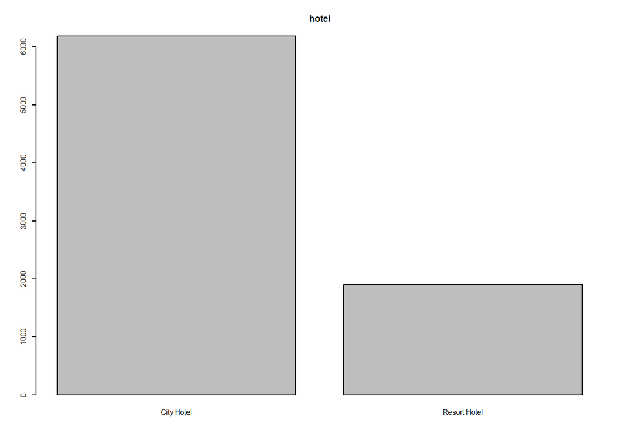

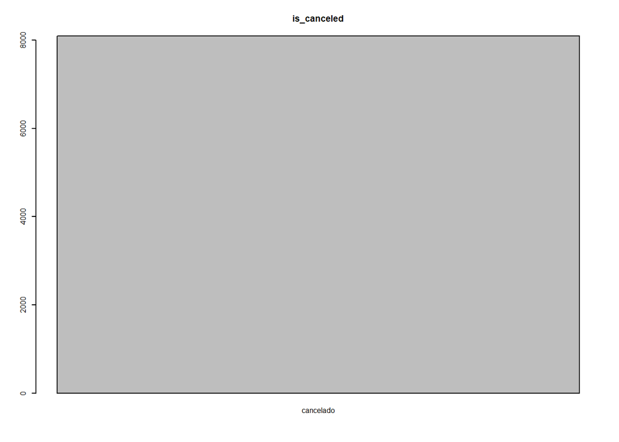

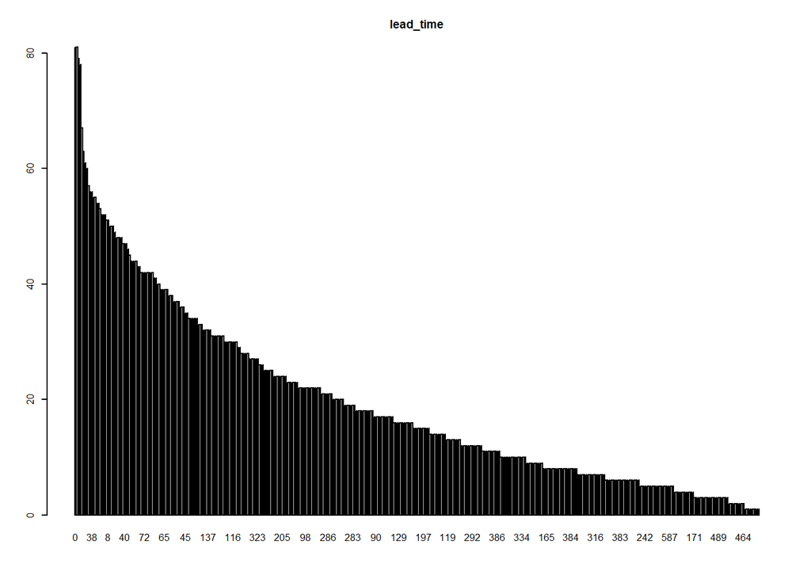

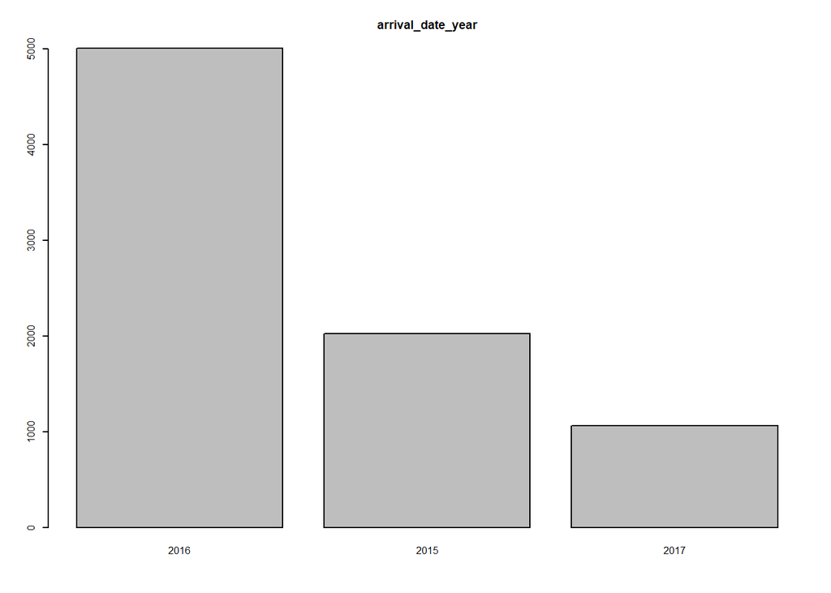

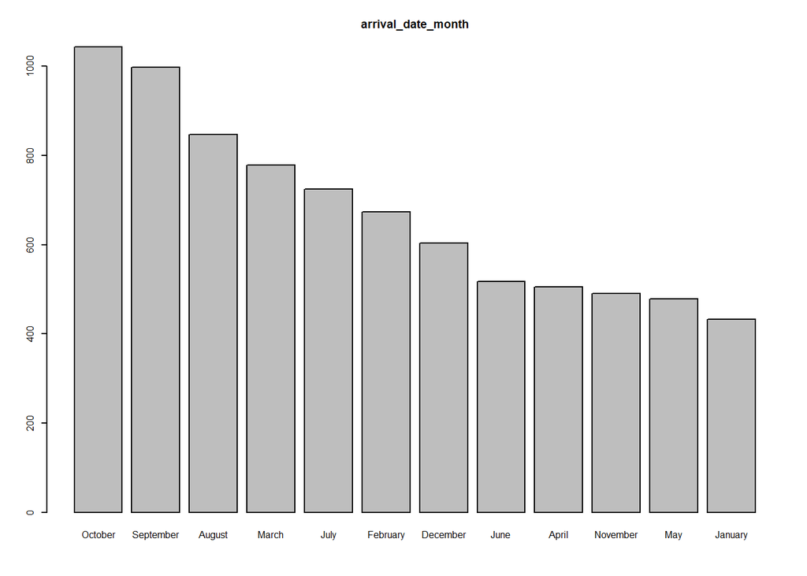

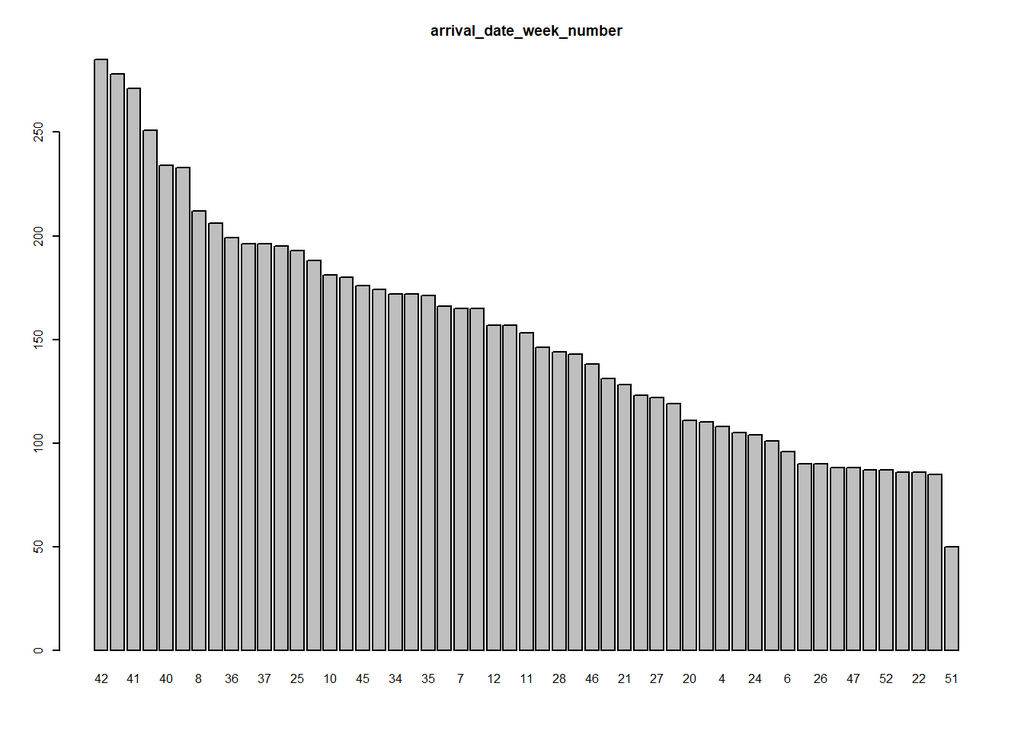

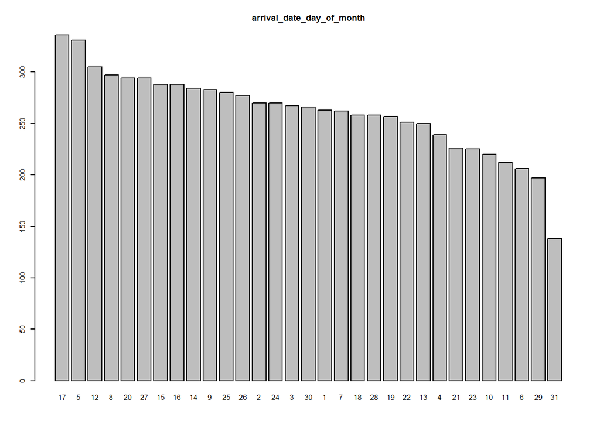

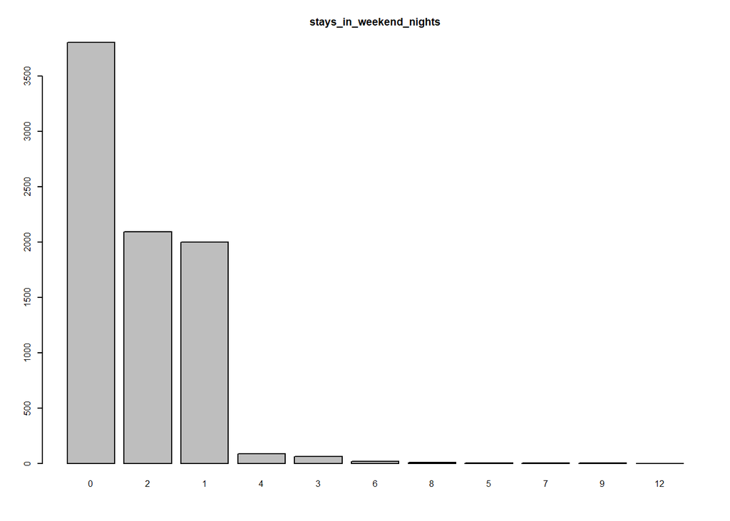

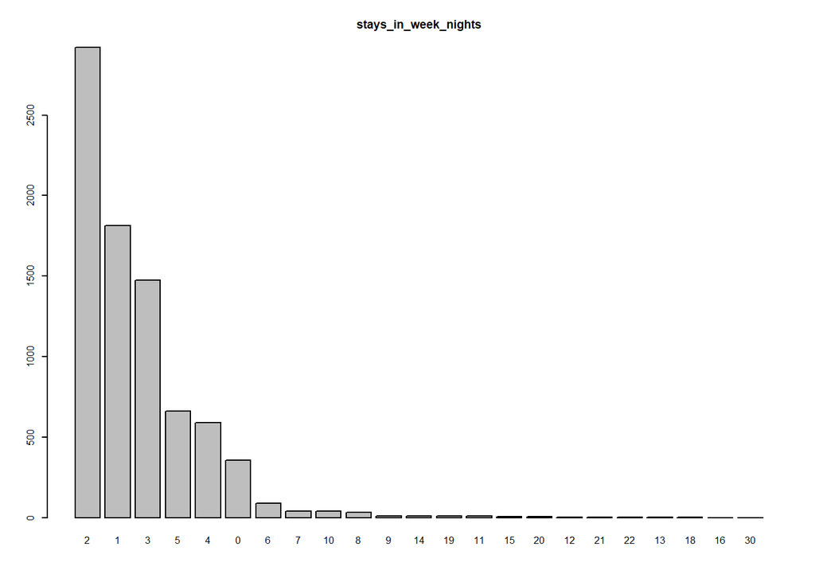

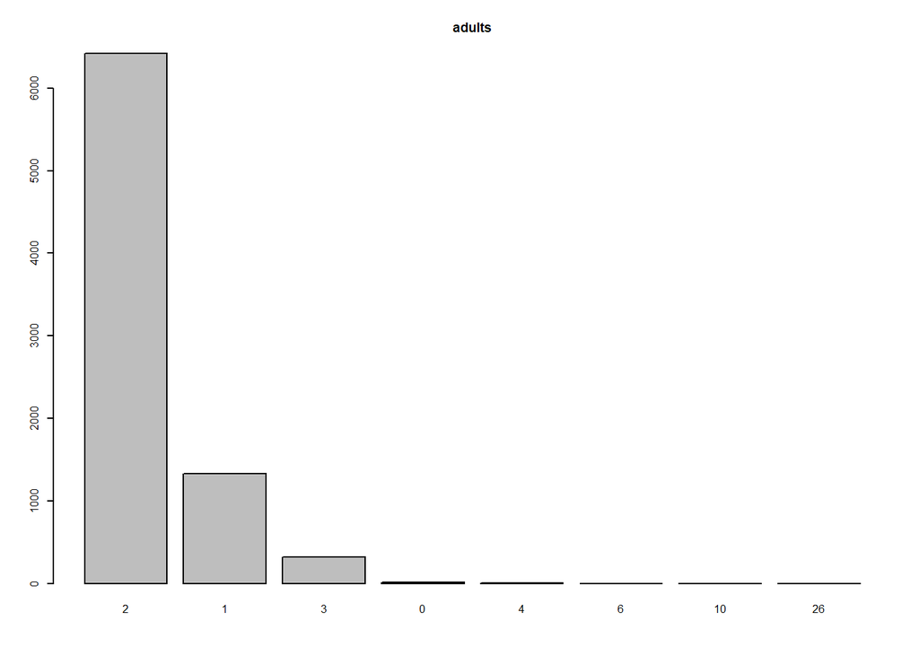

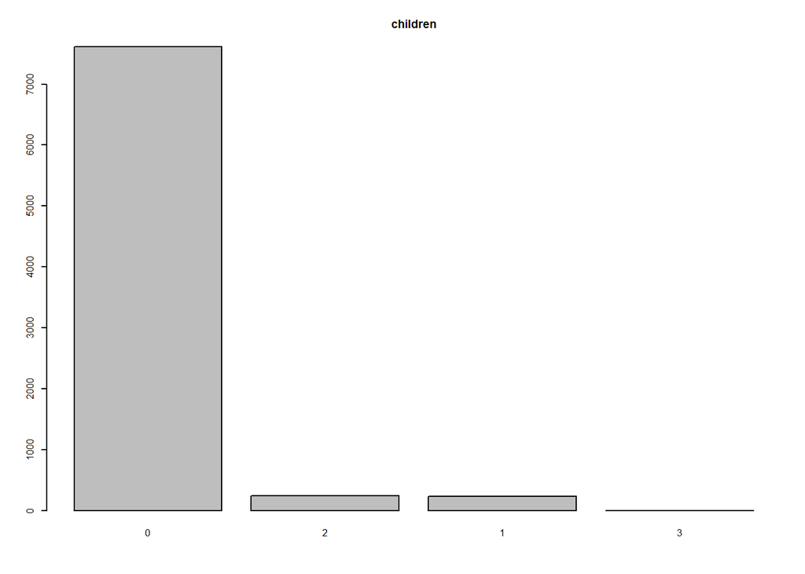

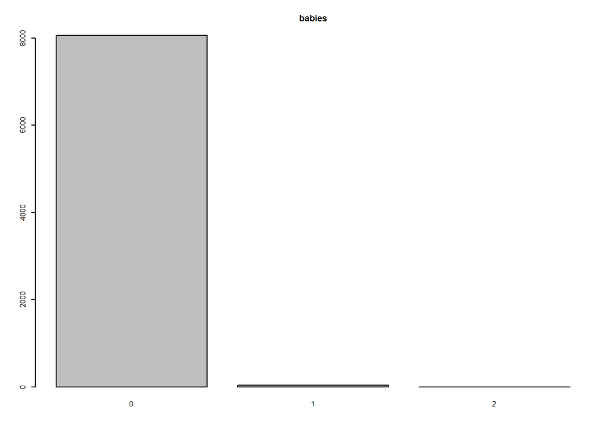

[18 more figures not shown]

#### Resultado de histogramas

Después de revisar cada uno de los histogramas encontramos que:

Hotel: hay una proporción considerablemente mayor de cancelaciones en la categoría City

arrival_date: observamos que la mayoría de los datos provienen de 2016 y muy pocos de 2017. nos hace pensar que la muestra fue tomada a partir de un mes intermedio de 2015 y cortada en un mes intermedio de 2017

Adults: la mayor cancelación proviene de 2 y 1 adulto, lo que puede hacernos pensar que pueden ser reservaciones para viajes de trabajo. también es importante considerar que en muchos hoteles las habitaciones son de máximo 3 ocupantes.

children y babies: la mayor concentración es de cero y puede reforzar el supuesto de adultos.

reserver_room_type y Assigned_room_type: los valores de las categorías están reservados por privacidad por lo que no se puede interpretar claramente esta variable, sin embargo, ambas están asocias a la categoría A. podríamos pensar que serían las estándar de 2 personas siguiendo el supuesto que las cancelaciones son mayormente por tipo de viaje de trabajo.

**Country:** esta variable presenta un dato totalmente atípico en la categoría PRT por lo que es importante considerarla ya que podría explicar una porción importante de las cancelaciones.

market_segment y distribution_channel: estas variables están relacionadas y tiene un sesgo a la categorías asociadas a las agencias de viajes y hechas online

**Deposit_type:** aqui hay otro caso ilógico, ya que la categoría de no rembolsable está muy por arriba de los rembolsable, uno pensaría que debería ser menos frecuenta la cancelación si no te van a devolver tu dinero. por lo que es otra variable importante.

**agent:** podría ser otra variable interesante porque el agente 9 tiene muchas cancelaciones

customer_type. la categoría con más reservaciones es Transient que es cuando la reserva no es parte de un grupo o contrato, y no asociado a otras reservas transitorias

Adr. es otra variable que puede ser interesante porque tiene una frecuencia muy alta en el valor 62. se puede hacer el supuesto que es promedio de la mayoría de las habitaciones dobles. siguen el supuesto anterior.

las demás variables no proporcionan información de mayor interés en esta primera revisión.

#### Primera revisión de varables interesantes

Primero revisamos si hay alguna relacion entre las variables interesantes

##### Analisando la variable deposit_type

se extrae el subset de deposit_type cancelados

```r
sub_rembolso <- subset(sub_cancelados, deposit_type == "Non Refund")
```

revisamos los porcentajes de cada catagoria en las otras variables

```r
a <- table(sub_rembolso$country)
prop <- prop.table(a)
prop
```

```
##
##         BEL          CN         ESP         FRA         GBR        NULL
## 0.000349162 0.000698324 0.010125698 0.000698324 0.010125698 0.001047486
##         POL         PRT
## 0.002793296 0.974162011
```

## Hallazgo 1 observamos que el 97% de las cancelaciones sin rembolso pertenecen al país PRT

```r
a <- table(sub_rembolso$agent)
prop <- prop.table(a)
prop
```

```
##
##           1          10          11         119          12         132
## 0.345321229 0.000349162 0.005237430 0.014315642 0.019203911 0.002094972
##         133         134         147          15         154         155
## 0.004189944 0.004888268 0.000698324 0.003491620 0.006983240 0.002793296
##         162         170         171         182         183          19
## 0.003840782 0.000349162 0.005237430 0.000349162 0.000349162 0.048533520
##         191         192          20         208          21          22
## 0.000349162 0.001745810 0.009078212 0.002094972 0.032821229 0.001047486
##         235         236         240         245         248         252
## 0.001396648 0.019902235 0.002444134 0.001047486 0.004189944 0.001745810
##         253         257          26         273         287          29
## 0.000349162 0.003142458 0.008030726 0.006983240 0.001047486 0.045041899
##         298           3          30         305          31         310
## 0.002094972 0.045041899 0.002444134 0.002793296 0.010125698 0.001745810
##         326         332          34          35          37         378
## 0.012220670 0.002094972 0.012569832 0.004539106 0.045041899 0.002444134
##          38          39           4          41          44         495
## 0.007332402 0.002793296 0.000349162 0.005237430 0.012220670 0.004539106
##           5          50          53          56          58           6
## 0.005935754 0.000698324 0.001396648 0.004888268 0.009078212 0.049930168
##          60          64          67          68          71          78
## 0.001396648 0.001396648 0.001745810 0.013617318 0.002793296 0.003142458
##          82          86          96          98        NULL
## 0.003142458 0.005237430 0.011871508 0.004189944 0.093226257
```

obsevamos que el 34% de las cancelaciones sin rembolso son del agente 1

#### Analisando la variable agent

Revisamos el subset de agentes cancelados

```r
a <- table(sub_cancelados$agent)
prop <- prop.table(a)
prop
```

```
##
##            1           10          103          105          107           11
## 0.1574394464 0.0011122096 0.0001235788 0.0001235788 0.0001235788 0.0024715769
##          110          115          118          119           12          126
## 0.0002471577 0.0006178942 0.0006178942 0.0065496787 0.0082797825 0.0001235788
##           13          132          133          134          138           14
## 0.0008650519 0.0011122096 0.0016065250 0.0087740979 0.0008650519 0.0135936728
##          142          143          146          147          149           15
## 0.0009886307 0.0003707365 0.0003707365 0.0009886307 0.0001235788 0.0028423134
##          151          153          154          155          156          157
## 0.0001235788 0.0002471577 0.0027187346 0.0014829461 0.0004943154 0.0004943154
##           16          162          168           17          170          171
## 0.0006178942 0.0013593673 0.0001235788 0.0046959960 0.0001235788 0.0035837865
##          173          174          175          177          181          182
## 0.0002471577 0.0001235788 0.0007414731 0.0012357884 0.0003707365 0.0001235788
##          183          184          185          187           19          191
## 0.0001235788 0.0001235788 0.0003707365 0.0001235788 0.0186604053 0.0033366288
##          192          195          196            2           20          201
## 0.0007414731 0.0012357884 0.0019772615 0.0003707365 0.0053138903 0.0001235788
##          208           21          210          214           22          220
## 0.0028423134 0.0163124073 0.0001235788 0.0001235788 0.0012357884 0.0001235788
##          234          235          236          240          241          242
## 0.0013593673 0.0004943154 0.0070439941 0.1096144340 0.0040781018 0.0043252595
##          243          245          248          249          250          252
## 0.0002471577 0.0003707365 0.0021008403 0.0013593673 0.0102570440 0.0006178942
##          253          254          257           26          261          262
## 0.0002471577 0.0002471577 0.0011122096 0.0035837865 0.0003707365 0.0001235788
##           27          270          273           28          281          287
## 0.0009886307 0.0001235788 0.0032130499 0.0027187346 0.0012357884 0.0003707365
##           29          296          298            3           30          305
## 0.0180425111 0.0001235788 0.0032130499 0.0206376668 0.0044488384 0.0009886307
##           31          310          314          315          326          330
## 0.0035837865 0.0006178942 0.0023479980 0.0022244192 0.0044488384 0.0003707365
##          332          336          339           34          341          348
## 0.0009886307 0.0001235788 0.0006178942 0.0051903114 0.0001235788 0.0001235788
##           35           36          368           37          375          378
## 0.0019772615 0.0003707365 0.0001235788 0.0174246169 0.0001235788 0.0008650519
##           38          385          387           39          393            4
## 0.0042016807 0.0002471577 0.0002471577 0.0009886307 0.0001235788 0.0008650519
##           40          405           41           42           44          440
## 0.0006178942 0.0001235788 0.0018536826 0.0001235788 0.0045724172 0.0013593673
##          464           47          495            5           50           52
## 0.0001235788 0.0001235788 0.0016065250 0.0035837865 0.0002471577 0.0004943154
##           53           56           57           58            6           60
## 0.0004943154 0.0069204152 0.0001235788 0.0039545230 0.0257043994 0.0004943154
##           64           66           67           68            7           71
## 0.0004943154 0.0001235788 0.0017301038 0.0051903114 0.0119871478 0.0009886307
##           78           79            8           81           82           83
## 0.0011122096 0.0002471577 0.0096391498 0.0001235788 0.0012357884 0.0043252595
##           85           86           87           89            9           91
## 0.0018536826 0.0033366288 0.0006178942 0.0001235788 0.2757043994 0.0002471577
##           94           95           96           98           99         NULL
## 0.0003707365 0.0007414731 0.0074147306 0.0014829461 0.0009886307 0.0829214039
```

se extrae el subset del agente 1 cancelados

```r
sub_agent <- subset(sub_cancelados, agent == "1")
```

```r
a <- table(sub_agent$country)
prop <- prop.table(a)
prop
```

```
##
##          ESP          FRA          PRT
## 0.0117739403 0.0007849294 0.9874411303
```

tambien observamos una relacion entre el agente 1 y el pais PRT

##### Analisando la variable county

se extrae el subset de county cancelados

```r
sub_country <- subset(sub_cancelados, country == "PRT")
```

revisamos los porcentajes de cada catagoria en las otras variables

```r
a <- table(sub_country$agent)
prop <- prop.table(a)
prop
```

```
##
##            1           10          103          105          107           11
## 0.2295201606 0.0016420361 0.0001824485 0.0001824485 0.0001824485 0.0036489692
##          110          115          118          119           12          126
## 0.0003648969 0.0009122423 0.0009122423 0.0096697683 0.0116767013 0.0001824485
##           13          132          133          134          138           14
## 0.0012771392 0.0016420361 0.0023718300 0.0122240467 0.0012771392 0.0056559022
##          142          143          146          147          149           15
## 0.0007297938 0.0005473454 0.0005473454 0.0014595877 0.0001824485 0.0038314176
##          151          153          154          155          156          157
## 0.0001824485 0.0001824485 0.0040138661 0.0020069330 0.0007297938 0.0007297938
##           16          162          168          170          171          173
## 0.0009122423 0.0020069330 0.0001824485 0.0001824485 0.0052910053 0.0003648969
##          174          175          177          181          182          184
## 0.0001824485 0.0010946907 0.0018244846 0.0005473454 0.0001824485 0.0001824485
##          185          187           19          191          192          195
## 0.0005473454 0.0001824485 0.0275497172 0.0049261084 0.0010946907 0.0001824485
##          196            2           20          201          208           21
## 0.0029191753 0.0005473454 0.0078452837 0.0001824485 0.0041963145 0.0240831965
##          210          214           22          220          234          235
## 0.0001824485 0.0001824485 0.0018244846 0.0001824485 0.0020069330 0.0007297938
##          236          240          241          242          243          245
## 0.0103995621 0.0961503375 0.0060207991 0.0058383507 0.0003648969 0.0005473454
##          248          249          250          252          253          254
## 0.0031016238 0.0020069330 0.0093048714 0.0009122423 0.0003648969 0.0003648969
##          257           26          261          262           27          270
## 0.0016420361 0.0051085568 0.0005473454 0.0001824485 0.0014595877 0.0001824485
##          273           28          281          287           29          296
## 0.0023718300 0.0040138661 0.0018244846 0.0005473454 0.0266374749 0.0001824485
##          298            3           30          305           31          310
## 0.0047436599 0.0304688925 0.0065681445 0.0014595877 0.0052910053 0.0009122423
##          314          315          326          330          332          336
## 0.0034665207 0.0032840722 0.0065681445 0.0005473454 0.0014595877 0.0001824485
##          339           34          341          348           35           36
## 0.0009122423 0.0076628352 0.0001824485 0.0001824485 0.0029191753 0.0005473454
##          368           37          375          378           38          385
## 0.0001824485 0.0242656450 0.0001824485 0.0012771392 0.0062032476 0.0003648969
##          387           39          393            4           40          405
## 0.0003648969 0.0014595877 0.0001824485 0.0012771392 0.0009122423 0.0001824485
##           41           42           44          440          464           47
## 0.0027367269 0.0001824485 0.0067505930 0.0020069330 0.0001824485 0.0001824485
##          495            5           50           52           53           56
## 0.0023718300 0.0052910053 0.0003648969 0.0007297938 0.0007297938 0.0102171137
##           57           58            6           60           64           66
## 0.0001824485 0.0058383507 0.0379492793 0.0007297938 0.0007297938 0.0001824485
##           67           68            7           71           78           79
## 0.0025542784 0.0056559022 0.0171501551 0.0014595877 0.0016420361 0.0003648969
##            8           81           82           83           85           86
## 0.0138660828 0.0001824485 0.0018244846 0.0058383507 0.0025542784 0.0049261084
##           87           89            9           91           94           95
## 0.0009122423 0.0001824485 0.0498084291 0.0003648969 0.0005473454 0.0010946907
##           96           98           99         NULL
## 0.0082101806 0.0021893815 0.0014595877 0.1145776318
```

#### el 23 porciento de las reservaciones del pais PRT fueron realizadas con el agente 1

### las variables deposit_type, county y agent tienen una relacion directa entre el pais PRT, el agente 1 y reservacion sin rembolso

## Analisis de serie de tiempo

```r
knitr::opts_chunk$set(echo = FALSE, message = FALSE, results='hide')
library(tidyverse)
library(Hmisc)
library(skimr)
library(naniar)
library(patchwork)
library(plotly)
library(ggplot2)
library(DataExplorer)
library(knitr)
library(reshape2)
library(lubridate)
```

# leo datos

```r
data<-read.csv("data/entrena.csv",stringsAsFactors = F)
```

# Creo las 3 bases

```r
idx <- sample(seq(1, 3), size = nrow(data), replace = TRUE, prob = c(.7, 2, .1))
train <- data[idx == 1,]
test <- data[idx == 2,]
cal <- data[idx == 3,]
```

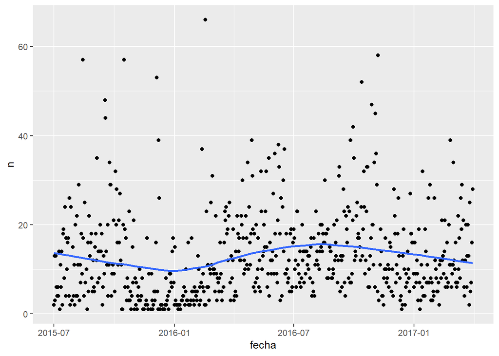

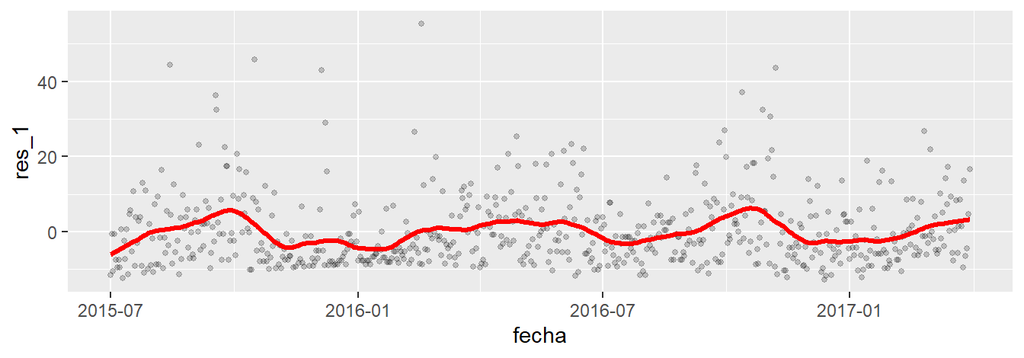

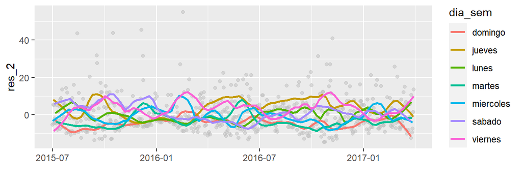

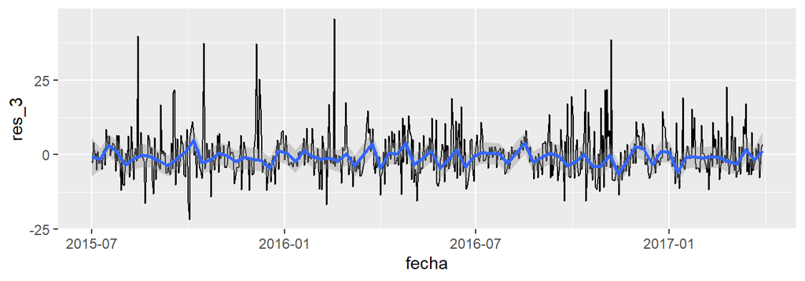

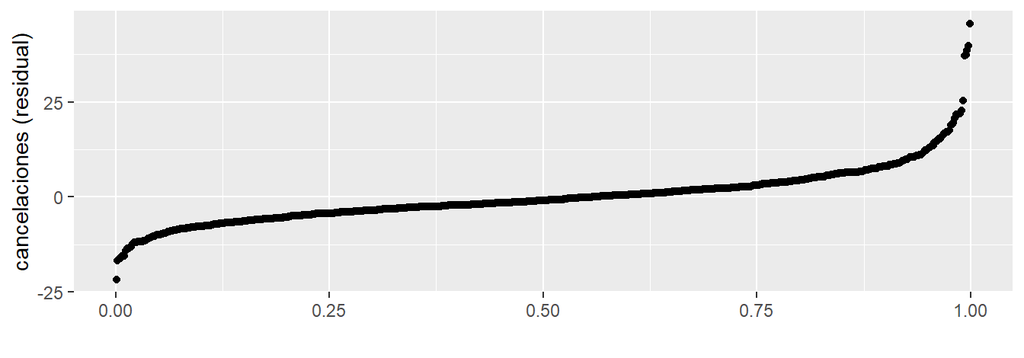

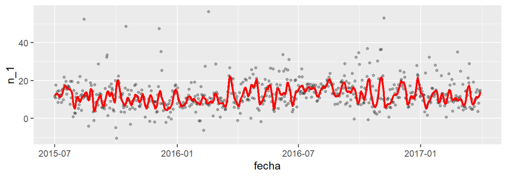

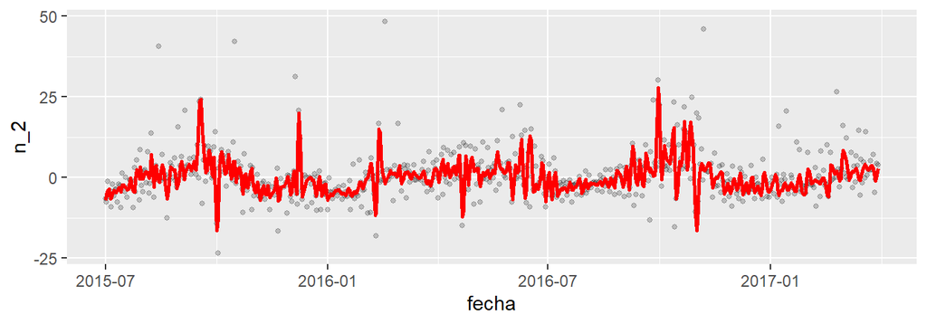

Y ahora repetimos con la componente de día de la semana:

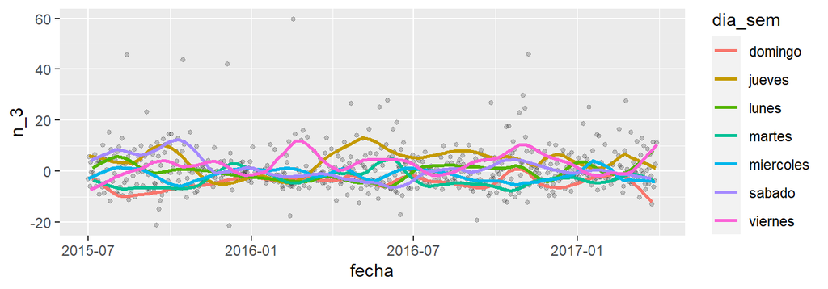

### Análisis de componentes

Ahora comparamos las componentes estimadas y los residuales en una misma gráfica. Por definición, la suma de todas estas componentes da los datos originales.

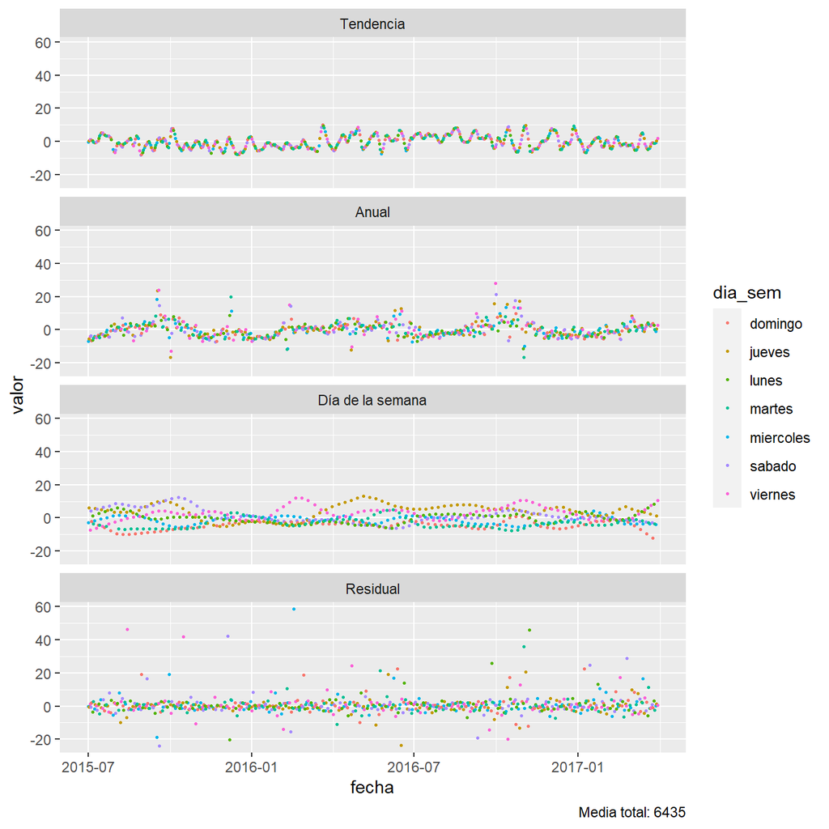